# PBMC 3k scRNA-seq Pipeline (Arrow + Seurat)

```r
# Install dependencies via pak (preferred)
# Set SKIP_PAK_INSTALL=1 to skip install during render.
# Set SKIP_R_RUN=1 to render without executing code chunks.
required_pkgs <- c("Seurat", "Matrix", "ggplot2", "dplyr", "tidyr", "arrow", "DESeq2")
if (!requireNamespace("pak", quietly = TRUE)) {
  install.packages("pak")
}
if (Sys.getenv("SKIP_PAK_INSTALL") != "1") {
  missing_pkgs <- required_pkgs[!sapply(required_pkgs, requireNamespace, quietly = TRUE)]
  if (length(missing_pkgs) > 0) {
    pak::pkg_install(missing_pkgs)
  }
}

if (Sys.getenv("SKIP_R_RUN") == "1") {
  knitr::opts_chunk$set(eval = FALSE)
} else {
  library(Seurat)
  library(Matrix)
  library(ggplot2)
  library(dplyr)
  library(arrow)
  library(tidyr)
}

DATASET <- "mannekuntanagendra/single-cell-rna-seq-analysis-qc-clustering-pbmc-3k"
DATA_DIR <- "data/pbmc3k"
OUTPUT_DIR <- "outputs"
ARROW_DIR <- file.path(OUTPUT_DIR, "arrow")

if (!dir.exists(OUTPUT_DIR)) dir.create(OUTPUT_DIR, recursive = TRUE)
if (!dir.exists(ARROW_DIR)) dir.create(ARROW_DIR, recursive = TRUE)
```

## Summary

End‑to‑end scRNA‑seq workflow on PBMC 3k: QC, normalization, feature selection, PCA/UMAP, clustering, marker discovery, and export of reusable artifacts.

## Get the Data

If you have Kaggle CLI configured, this will download and unzip the dataset. Otherwise, manually download from Kaggle and place the files inside `data/pbmc3k/`.

**Why this matters:** Data access should be reproducible and boring. This shows an automated download path with a manual fallback.

```r
ensure_data_dir <- function(path) {
  if (!dir.exists(path)) dir.create(path, recursive = TRUE)
}

has_kaggle_token <- function() {
  file.exists(file.path(path.expand("~"), ".kaggle", "kaggle.json"))
}

try_kaggle_download <- function(dataset, dest_dir) {
  ensure_data_dir(dest_dir)

  kaggle_bin <- Sys.which("kaggle")
  if (kaggle_bin == "" || !has_kaggle_token()) {
    return(invisible(FALSE))
  }

  args <- c("datasets", "download", "-d", dataset, "-p", dest_dir, "--unzip")
  system2(kaggle_bin, args = args)
  invisible(TRUE)
}

try_kaggle_download(DATASET, DATA_DIR)

list.files(DATA_DIR, recursive = TRUE)[1:10]
```

```
##  [1] "01_QC_Violin.png"
##  [2] "02_ElbowPlot.png"
##  [3] "03_UMAP_Clusters_Static.png"
##  [4] "07_Cluster_Markers.csv"
##  [5] "08_Heatmap_Top10.png"
##  [6] "09_Final_Annotated_UMAP.png"
##  [7] "3D UMAP Plot.png"
##  [8] "Automated End to End Single Cell RNA Seq Analysis Pipeline Quality Control Unsupervised Clustering and Interactive 3D Visualization PBMC 3k.pdf"
##  [9] "Automated End to End Single Cell RNA Seq Analysis Pipeline Quality Control Unsupervised Clustering and Interactive 3D Visualization PBMC 3k.R"
## [10] "Automated End to End Single Cell RNA Seq Analysis Pipeline Quality Control Unsupervised Clustering and Interactive 3D Visualization PBMC 3k.txt"
```

## Load Dataset

This attempts to load a 10x directory if present. The Kaggle PBMC 3k dataset typically ships with `matrix.mtx`, `features.tsv`, and `barcodes.tsv`.

**Why this matters:** 10x Genomics is the most common scRNA‑seq format, so it’s worth handling cleanly.

```r
load_dataset_auto <- function(data_dir) {
  mtx <- list.files(data_dir, pattern = "matrix.mtx", recursive = TRUE, full.names = TRUE)
  if (length(mtx) > 0) {
    return(Read10X(data.dir = dirname(mtx[1])))
  }

  stop("No supported files found. Expected 10x mtx directory.")
}

counts <- load_dataset_auto(DATA_DIR)
seu <- CreateSeuratObject(counts = counts, project = "pbmc3k")
seu
```

```
## An object of class Seurat
## 32738 features across 2700 samples within 1 assay
## Active assay: RNA (32738 features, 0 variable features)
##  1 layer present: counts
```

## Basic QC

**What happens here:** Compute per‑cell QC metrics and look at the distributions (library size, gene counts, mitochondrial fraction).

**Why this matters:** QC is where you separate biology from technical artifacts.

**Notes:** Mitochondrial percentage, total UMIs, and detected genes are standard diagnostics for cell viability and doublets. These plots make it easier to choose sensible thresholds.

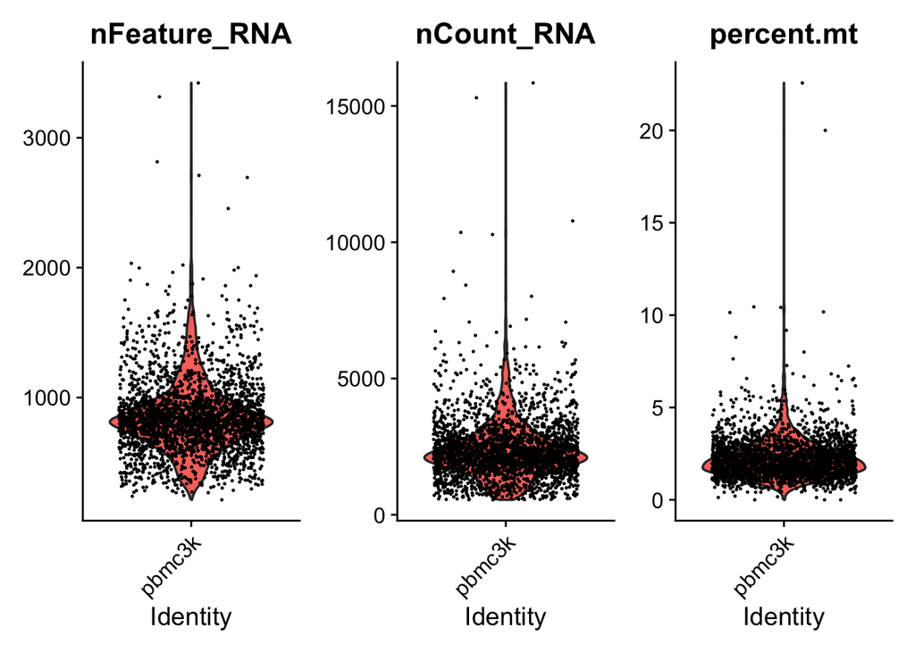

```r
seu[["percent.mt"]] <- PercentageFeatureSet(seu, pattern = "^MT-")

VlnPlot(seu, features = c("nFeature_RNA", "nCount_RNA", "percent.mt"), ncol = 3)
```

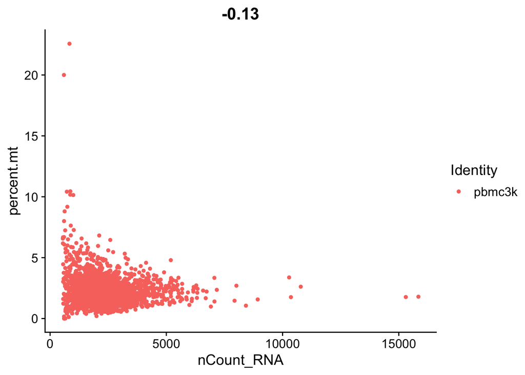

```r
FeatureScatter(seu, feature1 = "nCount_RNA", feature2 = "percent.mt")
```

```r
qc_tbl <- seu@meta.data %>%
  select(nFeature_RNA, nCount_RNA, percent.mt)
qc_tbl$cell_id <- rownames(seu@meta.data)

arrow::write_feather(qc_tbl, file.path(ARROW_DIR, "qc_metrics.feather"))
```

## Filter, Normalize, and Find Variable Features

**What happens here:** Filter low‑quality cells/genes, normalize counts, and select highly variable genes for downstream signal.

**Why this matters:** These are the standard preprocessing choices for scRNA‑seq.

**Notes:** Filtering removes sparse or damaged cells; log‑normalization stabilizes variance; highly variable genes capture the most informative biology and improve downstream dimensionality reduction.

```r
seu <- subset(seu, subset = nFeature_RNA > 200 & nFeature_RNA < 2500 & percent.mt < 15)

seu <- NormalizeData(seu)
```

```
## Normalizing layer: counts
```

```r
seu <- FindVariableFeatures(seu, selection.method = "vst", nfeatures = 2000)
```

```
## Finding variable features for layer counts
```

```r
seu <- ScaleData(seu)
```

## PCA, UMAP, Clustering

**What happens here:** Reduce dimensionality (PCA), build a neighborhood graph, embed with UMAP, and identify clusters.

**Why this matters:** Dimensionality reduction + clustering are the backbone of scRNA‑seq analysis.

```r
seu <- RunPCA(seu)
```

```
## PC_ 1
## Positive:  CST3, TYROBP, LST1, AIF1, FTL, FCN1, LYZ, FTH1, S100A9, FCER1G
##     TYMP, CFD, LGALS1, CTSS, S100A8, SERPINA1, LGALS2, SPI1, IFITM3, PSAP
##     CFP, SAT1, IFI30, COTL1, S100A11, NPC2, LGALS3, GSTP1, NCF2, PYCARD
## Negative:  MALAT1, LTB, IL32, IL7R, CD2, B2M, ACAP1, CTSW, GZMM, STK17A
##     CD247, CCL5, GIMAP5, AQP3, GZMA, CST7, TRAF3IP3, MAL, HOPX, GZMK
##     ITM2A, MYC, GIMAP7, ETS1, BEX2, LDLRAP1, ZAP70, LYAR, NKG7, KLRG1
## PC_ 2
## Positive:  NKG7, PRF1, CST7, GZMA, GZMB, FGFBP2, CTSW, GNLY, B2M, SPON2
##     GZMH, CCL4, FCGR3A, GZMM, CCL5, CD247, XCL2, CLIC3, AKR1C3, SRGN
##     HOPX, CTSC, TTC38, S100A4, IGFBP7, ANXA1, ID2, IL32, XCL1, ACTB
## Negative:  CD79A, MS4A1, TCL1A, HLA-DQA1, HLA-DQB1, HLA-DRA, LINC00926, CD79B, HLA-DRB1, CD74
##     HLA-DPB1, HLA-DMA, HLA-DQA2, HLA-DRB5, HLA-DPA1, HLA-DMB, FCRLA, HVCN1, LTB, BLNK
##     P2RX5, IGLL5, IRF8, SWAP70, ARHGAP24, PPP1R14A, SMIM14, C16orf74, FCRL2, MZB1
## PC_ 3
## Positive:  HLA-DQA1, CD79A, CD79B, HLA-DQB1, HLA-DPB1, HLA-DPA1, CD74, MS4A1, HLA-DRB1, HLA-DRB5
##     HLA-DRA, HLA-DQA2, TCL1A, LINC00926, HLA-DMB, HLA-DMA, HVCN1, FCRLA, IRF8, PLAC8
##     BLNK, MALAT1, SMIM14, PLD4, LAT2, P2RX5, IGLL5, SWAP70, FCGR3A, FGFBP2
## Negative:  PPBP, PF4, SDPR, SPARC, GNG11, NRGN, GP9, RGS18, TUBB1, HIST1H2AC
##     CLU, AP001189.4, ITGA2B, CD9, TMEM40, PTCRA, CA2, ACRBP, MMD, TREML1
##     NGFRAP1, F13A1, SEPT5, RUFY1, MPP1, CMTM5, TSC22D1, RP11-367G6.3, MYL9, GP1BA
## PC_ 4
## Positive:  HLA-DQA1, CD79A, CD79B, MS4A1, HLA-DQB1, CD74, HLA-DPB1, HLA-DPA1, HLA-DRB1, HLA-DQA2
##     TCL1A, HIST1H2AC, HLA-DRA, PF4, LINC00926, SDPR, HLA-DRB5, PPBP, GNG11, SPARC
##     GP9, PTCRA, CD9, RGS18, NRGN, CA2, AP001189.4, GZMB, CLU, HLA-DMA
## Negative:  VIM, IL7R, S100A6, S100A8, IL32, S100A4, S100A9, GIMAP7, S100A10, MAL
##     CD14, LGALS2, AQP3, FYB, CD2, RBP7, GIMAP4, FCN1, ANXA1, LYZ
##     S100A12, MS4A6A, S100A11, FOLR3, GIMAP5, AIF1, TMSB4X, TRABD2A, IL8, IFI6
## PC_ 5
## Positive:  LTB, IL7R, VIM, AQP3, CYTIP, CKB, MAL, MS4A7, PTGES3, PPA1
##     CD2, RP11-290F20.3, SIGLEC10, CORO1B, ANXA5, HN1, TUBA1B, HMOX1, TRADD, FYB
##     IL32, GDI2, LILRB2, TRAF3IP3, ABRACL, ATP1A1, GPR183, NDFIP1, TNFAIP8, ATP5C1
## Negative:  GZMB, NKG7, FGFBP2, GNLY, CCL4, S100A8, CST7, PRF1, GZMA, SPON2
##     GZMH, CLIC3, CCL3, S100A9, CTSW, XCL2, LGALS2, CCL5, RBP7, CD14
##     TTC38, AKR1C3, S100A12, TYROBP, MS4A6A, IGFBP7, GSTP1, XCL1, FOLR3, GZMM
```

```r
seu <- FindNeighbors(seu, dims = 1:20)
seu <- FindClusters(seu, resolution = 0.6)
```

```
## Modularity Optimizer version 1.3.0 by Ludo Waltman and Nees Jan van Eck
##
## Number of nodes: 2693
## Number of edges: 122169
##
## Running Louvain algorithm...
## Maximum modularity in 10 random starts: 0.8475
## Number of communities: 9
## Elapsed time: 0 seconds
```

```r
seu <- RunUMAP(seu, dims = 1:20)
```

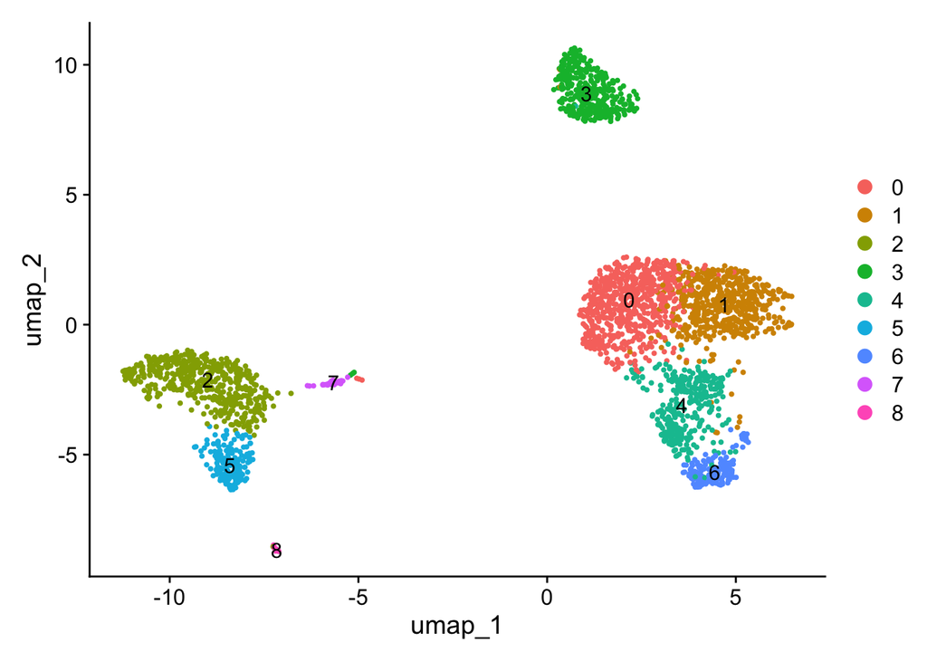

```r
DimPlot(seu, reduction = "umap", label = TRUE)
```

## Marker Genes

**What happens here:** Identify genes that are differentially expressed in each cluster.

**Why this matters:** Marker discovery drives cell‑type labeling and interpretation.

**Notes:** Differential expression across clusters highlights signature genes that can be matched to known cell types or used to discover novel states.

```r
message("Running DESeq2 marker tests (output condensed)...")
```

```
## Running DESeq2 marker tests (output condensed)...
```

```r
invisible(capture.output(
  markers <- suppressMessages(FindAllMarkers(
    seu,
    only.pos = TRUE,
    min.pct = 0.25,
    logfc.threshold = 0.25,
    test.use = "DESeq2",
    verbose = FALSE
  )),
  file = nullfile()
))
head(markers, 10)
```

```
##               p_val avg_log2FC pct.1 pct.2    p_val_adj cluster   gene
## IL7R   1.300431e-30  1.4942435 0.755 0.315 4.257350e-26       1   IL7R
## CD2    1.406711e-30  1.6161067 0.634 0.240 4.605291e-26       1    CD2
## LDHB   2.184684e-29  1.0873098 0.957 0.600 7.152220e-25       1   LDHB
## IL32   1.501442e-28  1.2666675 0.942 0.459 4.915422e-24       1   IL32
## LTB    4.058954e-23  1.3438474 0.979 0.634 1.328820e-18       1    LTB
## CD3D   1.130741e-18  1.0414010 0.913 0.424 3.701821e-14       1   CD3D
## GIMAP4 6.848744e-18  0.9084598 0.617 0.416 2.242142e-13       1 GIMAP4
## CD3E   8.325395e-16  1.0017386 0.813 0.400 2.725568e-11       1   CD3E
## PLP2   1.773122e-15  1.1269713 0.549 0.289 5.804846e-11       1   PLP2
## ANXA1  2.415399e-14  0.7148683 0.792 0.540 7.907535e-10       1  ANXA1
```

## DESeq2 Marker Plot

**What happens here:** Visualize DESeq2 marker test significance per cluster.

**Why this matters:** It makes the DESeq2-based marker ranking visible rather than only showing raw tables.

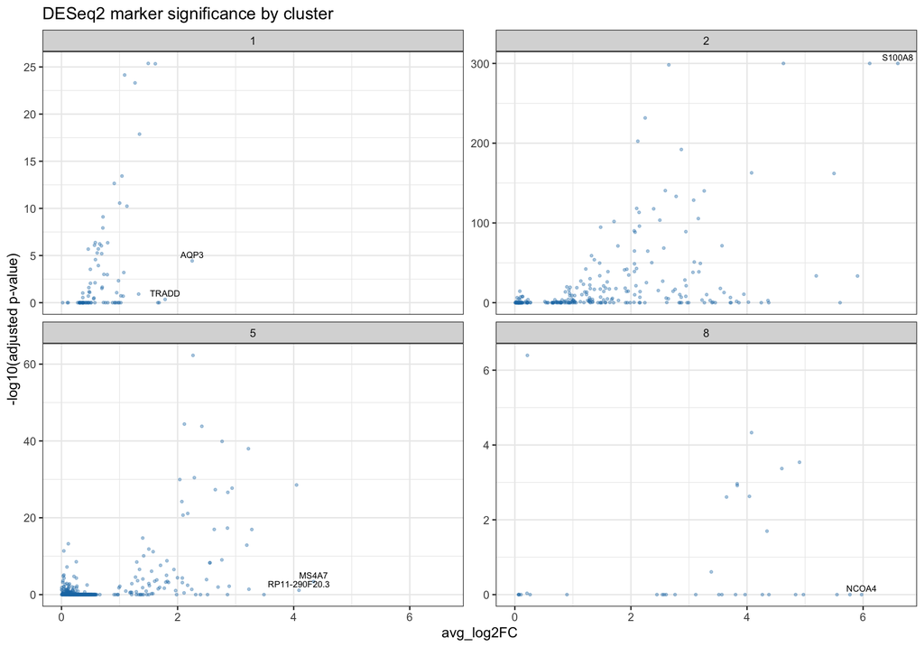

```r
marker_plot_df <- markers %>%
  filter(!is.na(p_val_adj), !is.na(avg_log2FC)) %>%
  mutate(
    cluster = factor(cluster),
    neg_log10_padj = -log10(pmax(p_val_adj, 1e-300))
  )

label_df <- marker_plot_df %>%
  group_by(cluster) %>%
  slice_max(order_by = avg_log2FC, n = 2, with_ties = FALSE) %>%
  ungroup()

ggplot(marker_plot_df, aes(x = avg_log2FC, y = neg_log10_padj)) +
  geom_point(alpha = 0.35, size = 0.7, color = "#1f78b4") +
  facet_wrap(~ cluster, scales = "free_y") +
  geom_text(
    data = label_df,
    aes(label = gene),
    size = 2.4,
    vjust = -0.5,
    check_overlap = TRUE
  ) +
  labs(
    title = "DESeq2 marker significance by cluster",
    x = "avg_log2FC",
    y = "-log10(adjusted p-value)"
  ) +
  theme_bw()
```

## Putative Cell‑Type Labels (Manual)

**What happens here:** Use canonical PBMC marker sets and cluster‑level scores to assign **putative** labels.  
These are best‑effort labels based on marker expression, not ground truth.

```r
marker_sets <- list(
  B_cells = c("MS4A1", "CD79A", "CD74"),
  T_cells = c("CD3D", "CD3E", "IL7R", "LTB"),
  NK_cells = c("NKG7", "GNLY", "PRF1"),
  Monocytes = c("LST1", "S100A8", "S100A9", "LYZ"),
  Dendritic = c("FCER1A", "CST3"),
  Platelets = c("PPBP", "PF4")
)

# Score each marker set per cell
seu <- AddModuleScore(seu, features = marker_sets, name = "celltype_score")

# Map scores back to names
score_cols <- paste0("celltype_score", seq_along(marker_sets))
score_df <- FetchData(seu, vars = c("seurat_clusters", score_cols))
colnames(score_df) <- c("cluster", names(marker_sets))

# Average score per cluster and assign the max
cluster_scores <- score_df %>%
  group_by(cluster) %>%
  summarise(across(all_of(names(marker_sets)), mean), .groups = "drop")

cluster_labels <- cluster_scores %>%
  pivot_longer(-cluster, names_to = "label", values_to = "score") %>%
  group_by(cluster) %>%
  slice_max(score, n = 1, with_ties = FALSE) %>%
  ungroup()

cluster_labels
```

```
## # A tibble: 9 × 3
##   cluster label     score
##   <fct>   <chr>     <dbl>
## 1 0       T_cells    1.08
## 2 1       T_cells    1.32
## 3 2       Monocytes  3.22
## 4 3       B_cells    2.59
## 5 4       NK_cells   1.04
## 6 5       Monocytes  1.56
## 7 6       NK_cells   3.18
## 8 7       Dendritic  2.86
## 9 8       Platelets  5.31
```

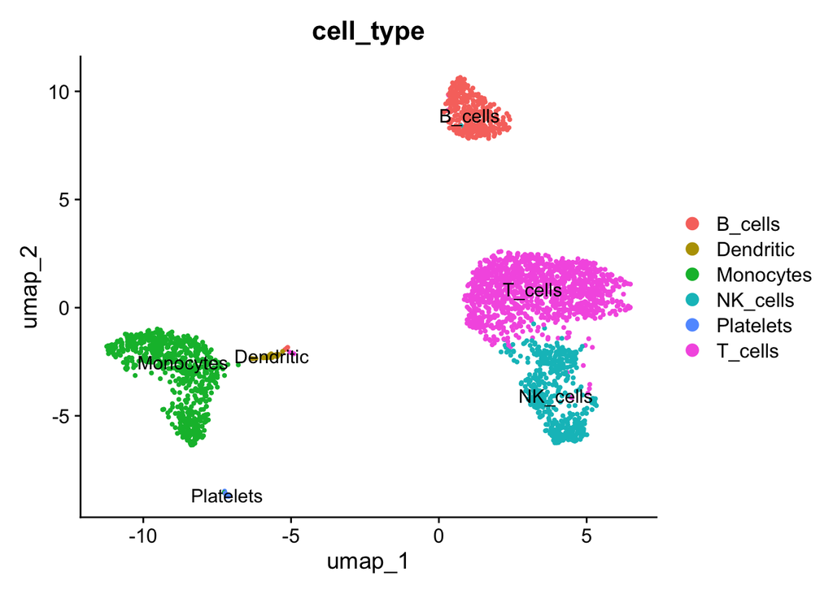

```r
label_map <- setNames(cluster_labels$label, cluster_labels$cluster)
cell_type_vec <- label_map[as.character(seu$seurat_clusters)]
names(cell_type_vec) <- colnames(seu)
seu <- AddMetaData(seu, metadata = cell_type_vec, col.name = "cell_type")
DimPlot(seu, reduction = "umap", group.by = "cell_type", label = TRUE)
```

## Selected Gene Boxplots

**What happens here:** Visualize expression of canonical immune markers across clusters.

**Why this matters:** These plots help validate cluster identities.

**Why these genes:** `MS4A1` (B cells), `CD3D` (T cells), `LST1` (monocytes), and `NKG7`/`GNLY` (NK/cytotoxic cells) are canonical PBMC markers that usually separate major immune lineages.

**Notes:** Boxplots summarize expression distributions and outliers, making cluster‑level differences easy to compare.

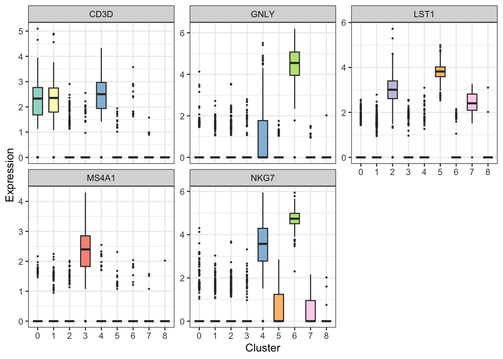

```r
marker_genes <- c("MS4A1", "CD3D", "LST1", "NKG7", "GNLY")

gene_df <- FetchData(seu, vars = c("seurat_clusters", marker_genes))
gene_long <- gene_df %>%
  pivot_longer(cols = all_of(marker_genes), names_to = "gene", values_to = "expression")

ggplot(gene_long, aes(x = seurat_clusters, y = expression, fill = seurat_clusters)) +
  geom_boxplot(outlier.size = 0.4, width = 0.6, alpha = 0.85) +
  facet_wrap(~ gene, scales = "free_y", ncol = 3) +
  labs(x = "Cluster", y = "Expression") +
  scale_fill_brewer(palette = "Set3") +
  theme_bw() +
  theme(legend.position = "none")
```

## Save Outputs

**What happens here:** Save a Seurat object for reuse and export lightweight Arrow tables for downstream consumption.

**Why this matters:** Keeps the results portable, not just in plots.

```r
saveRDS(seu, file.path(OUTPUT_DIR, "pbmc3k_seurat.rds"))

cluster_tbl <- seu@meta.data %>%
  select(nFeature_RNA, nCount_RNA, percent.mt, seurat_clusters)
cluster_tbl$cell_id <- rownames(seu@meta.data)

arrow::write_feather(cluster_tbl, file.path(ARROW_DIR, "cell_clusters.feather"))
```